# Clustering

## Internet Analytics - Lab 3

**Group**: J

**Names**:

- Maxime LANVIN
- Victor SALVIA
- Axel SJÖBERG

In this notebook we will:

- Use k-means on the low-dimensional embedding of tags we extracted earlier using PCA.
- We will implement a variant of k-means that enables the use of non-Euclidean distances, and we will cluster movies based on genres

```python
import json
import matplotlib.pyplot as plt
import numpy as np
import pickle
from sklearn.cluster import KMeans
from operator import itemgetter
from bokeh.palettes import Dark2_8
from bokeh.io import show, output_notebook
from bokeh.plotting import figure, ColumnDataSource
from bokeh.models import HoverTool, ResetTool, PanTool, WheelZoomTool, SaveTool
output_notebook()
from random import randint
import random

%matplotlib inline
plt.style.use("ggplot")
```

```python
tags = sc.textFile("/ix/ml-20m/genome-tags.txt").map(json.loads)
tag_scores = sc.textFile("/ix/ml-20m/genome-scores.txt").map(json.loads)
movies_ini = sc.textFile("/ix/ml-20m/movies.txt").map(json.loads)

IDT = dict(tags.map(itemgetter("tagId", "tag")).collect())
IDM = dict(movies_ini.map(itemgetter("movieId", "title")).collect())
```

```python
M = 1128 # tags
N = 10381 # movies with tags
```

```python
matrix = tag_scores.map(itemgetter("tagId", "movieId", "relevance"))
matrix = np.asarray(matrix.collect())
```

```python
n = len(matrix)
X = np.zeros((1128,10381)) # 1128 tags, 10381 movies
m = -1
moviesID = np.zeros(10381)

for i in range(0,n):
    if i % 1128 == 0:
        m = m + 1
        moviesID[m] = matrix[i][1]

    X[int(matrix[i][0])-1][m] = matrix[i][2]
```

# EXERCISE 3.11: Clustering Tags

Load the tag embedding that you created at the end of Exercise 3.2.

- Cluster the data using the k-means clustering algorithm. Try k ∈ {2,...,5}.
- Visualize the clusters using an interactive bokeh plot.
- Try projecting on different principal directions.

Which principal directions separate the clusters well?

```python
with open("tag_to_5pc", "rb") as f:
    tag_to_5pc = pickle.load(f, encoding="utf-8") # This is a dictionary --> dic[tagID] = [pc1,...,pc5]
```

```python
PC5 = np.zeros((M,5))
for i in range(1,M+1):
    PC5[i-1,:] = tag_to_5pc[i]

pc1 = PC5[:,0]
pc2 = PC5[:,1]
pc3 = PC5[:,2]
pc4 = PC5[:,3]
pc5 = PC5[:,4]
```

## K-means clustering

Recall that this is an iterative algorithm in which we:

1. Initialize $K$ means for the different clusters at random.
2. Iterate the following process until convergence:
   - Assign each data point the closest mean.
   - Update the mean as the center of mass of its points.

We will try with $K \in \{2,...,5\}$.

We will project all the movies in the low-dimensional space generated by the 5 principal components saved earlier. Once we run the algorithm in this space we will project it in different components to be able to visualize the results.

**Projection:** (which theory we explained in the first notebook)

```python
X_pro = np.dot(np.transpose(PC5), X) # this is the projection of all the data points in the first 5 components.
```

```python
km2 = KMeans(n_clusters=2, init='random', n_init=10, max_iter=300, tol=1e-04).fit(np.transpose(X_pro)) # it runs 10 times.
km3 = KMeans(n_clusters=3, init='random', n_init=10, max_iter=300, tol=1e-04).fit(np.transpose(X_pro))
km4 = KMeans(n_clusters=4, init='random', n_init=10, max_iter=300, tol=1e-04).fit(np.transpose(X_pro))
km5 = KMeans(n_clusters=5, init='random', n_init=10, max_iter=300, tol=1e-04).fit(np.transpose(X_pro))
```

```python
a = km5.cluster_centers_
a[0][2:4]
```

```
array([-0.17784656, -0.1618281 ])
```

```python
km5.predict(a[0].reshape(1,5))
```

```
array([0], dtype=int32)
```

## Visualize the result in 2D for the different K's (try different PC's)

We will now project the results in a 2D space and visualize the results. Also, we will try different PC's to see which combination works best for the sake of visualization. We will use the selected movies as well for the sake of visualization as well.

```python
with open("selected-movies.pickle", "rb") as f:
    movies = pickle.load(f, encoding="utf-8")
```

### K = 2

```python
l = []
for i, e in enumerate(movies):
    # First of all the vector:
    aux_id = e[0]
    aux = np.where(moviesID == aux_id)
    x_e = X[:,aux].reshape(M,1) # This is the vector of movies

    # Projection of score to eigenvectors:
    x_v = np.dot(np.transpose(PC5),x_e) # first 2 components coordinates are projection :)
    x_v = x_v[0:5].reshape(1,5)

    l.append([float(x_v[0,0]),float(x_v[0,1]),e[1],int(km2.predict(x_v))]) # (x_1,x_2,title,category)



data = l
source = ColumnDataSource(
    data={
        "x": [x[0] for x in data],
        "y": [x[1] for x in data],
        "name": [x[2] for x in data],
        "color": [Dark2_8[x[3]] for x in data],
    })

hover = HoverTool(
    tooltips=[
        ("Name", "@name"),
    ])
tools = [hover, ResetTool(), PanTool(), WheelZoomTool(), SaveTool()]

p = figure(plot_width=960, plot_height=360, tools=tools, title="K = 2", x_axis_label = "PC1", y_axis_label = "PC2")
p.circle("x", "y", source=source, size=20, color="color", alpha=0.5)
show(p, notebook_handle=True)
```

[interactive chart not shown]

`<Bokeh Notebook handle for In[14]>`

```python
l = []
for i, e in enumerate(movies):
    # First of all the vector:
    aux_id = e[0]
    aux = np.where(moviesID == aux_id)
    x_e = X[:,aux].reshape(M,1) # This is the vector of movies

    # Projection of score to eigenvectors:
    x_v = np.dot(np.transpose(PC5),x_e) # first 2 components coordinates are projection :)
    x_v = x_v[0:5].reshape(1,5)

    l.append([float(x_v[0,3]),float(x_v[0,4]),e[1],int(km2.predict(x_v))]) # (x_1,x_2,title,category)



data = l
source = ColumnDataSource(
    data={
        "x": [x[0] for x in data],
        "y": [x[1] for x in data],
        "name": [x[2] for x in data],
        "color": [Dark2_8[x[3]] for x in data],
    })

hover = HoverTool(
    tooltips=[
        ("Name", "@name"),
    ])
tools = [hover, ResetTool(), PanTool(), WheelZoomTool(), SaveTool()]

p = figure(plot_width=960, plot_height=360, tools=tools, title="K = 2", x_axis_label = "PC4", y_axis_label = "PC5")
p.circle("x", "y", source=source, size=20, color="color", alpha=0.5)
show(p, notebook_handle=True)
```

[interactive chart not shown]

`<Bokeh Notebook handle for In[15]>`

**Which principal components separate best?**

In the first graph the visualization is using the first 2 components, which clearly help us best than in this extreme case the last 2. This was expected since the highest components caputre more variance and therefore it is easier to separate classes using them. From now on we will keep using the first 2 components!

### K = 3

```python
l = []
for i, e in enumerate(movies):
    # First of all the vector:
    aux_id = e[0]
    aux = np.where(moviesID == aux_id)
    x_e = X[:,aux].reshape(M,1) # This is the vector of movies

    # Projection of score to eigenvectors:
    x_v = np.dot(np.transpose(PC5),x_e) # first 2 components coordinates are projection :)
    x_v = x_v[0:5].reshape(1,5)

    l.append([float(x_v[0,0]),float(x_v[0,1]),e[1],int(km3.predict(x_v))]) # (x_1,x_2,title,category)



data = l
source = ColumnDataSource(
    data={
        "x": [x[0] for x in data],
        "y": [x[1] for x in data],
        "name": [x[2] for x in data],
        "color": [Dark2_8[x[3]] for x in data],
    })

hover = HoverTool(
    tooltips=[
        ("Name", "@name"),
    ])
tools = [hover, ResetTool(), PanTool(), WheelZoomTool(), SaveTool()]

p = figure(plot_width=960, plot_height=360, tools=tools, title="K = 2", x_axis_label = "PC1", y_axis_label = "PC2")
p.circle("x", "y", source=source, size=20, color="color", alpha=0.5)
show(p, notebook_handle=True)
```

[interactive chart not shown]

`<Bokeh Notebook handle for In[16]>`

### K = 4

```python
l = []
for i, e in enumerate(movies):
    # First of all the vector:
    aux_id = e[0]
    aux = np.where(moviesID == aux_id)
    x_e = X[:,aux].reshape(M,1) # This is the vector of movies

    # Projection of score to eigenvectors:
    x_v = np.dot(np.transpose(PC5),x_e) # first 2 components coordinates are projection :)
    x_v = x_v[0:5].reshape(1,5)

    l.append([float(x_v[0,0]),float(x_v[0,1]),e[1],int(km4.predict(x_v))]) # (x_1,x_2,title,category)



data = l
source = ColumnDataSource(
    data={
        "x": [x[0] for x in data],
        "y": [x[1] for x in data],
        "name": [x[2] for x in data],
        "color": [Dark2_8[x[3]] for x in data],
    })

hover = HoverTool(
    tooltips=[
        ("Name", "@name"),
    ])
tools = [hover, ResetTool(), PanTool(), WheelZoomTool(), SaveTool()]

p = figure(plot_width=960, plot_height=360, tools=tools, title="K = 2", x_axis_label = "PC1", y_axis_label = "PC2")
p.circle("x", "y", source=source, size=20, color="color", alpha=0.5)
show(p, notebook_handle=True)
```

[interactive chart not shown]

`<Bokeh Notebook handle for In[17]>`

### K = 5

```python
l = []
for i, e in enumerate(movies):
    # First of all the vector:
    aux_id = e[0]
    aux = np.where(moviesID == aux_id)
    x_e = X[:,aux].reshape(M,1) # This is the vector of movies

    # Projection of score to eigenvectors:
    x_v = np.dot(np.transpose(PC5),x_e) # first 2 components coordinates are projection :)
    x_v = x_v[0:5].reshape(1,5)

    l.append([float(x_v[0,0]),float(x_v[0,1]),e[1],int(km5.predict(x_v))]) # (x_1,x_2,title,category)



data = l
source = ColumnDataSource(
    data={
        "x": [x[0] for x in data],
        "y": [x[1] for x in data],
        "name": [x[2] for x in data],
        "color": [Dark2_8[x[3]] for x in data],
    })

hover = HoverTool(
    tooltips=[
        ("Name", "@name"),
    ])
tools = [hover, ResetTool(), PanTool(), WheelZoomTool(), SaveTool()]

p = figure(plot_width=960, plot_height=360, tools=tools, title="K = 2", x_axis_label = "PC1", y_axis_label = "PC2")
p.circle("x", "y", source=source, size=20, color="color", alpha=0.5)
show(p, notebook_handle=True)
```

[interactive chart not shown]

`<Bokeh Notebook handle for In[18]>`

# EXERCISE 3.12: Clustering movies

Create a dict that maps movie IDs to set of genres from the data in movies.txt.

- Implement the k-medioids algorithm with the Jaccard distance.
- Cluster the set of movies in the file most-rated.pickle, using k = 2.
- Find a good way to visualize the results of the clustering. For example, you could try to visually represent the frequency of the genres in each of the clusters.

How do you intepret the two clusters?

Let us define the Jaccard distance between two sets $A$ and $B$:

$$d(A,B) = 1 - \frac{| A \cap B |}{| A \cup B |}$$

Now the problem is that there is **not a clear sense of center**, and **visualizing the space is challenging**. To solve the former, we will pick the point within the cluster which is closest to all others.

**NOTE:** In our case the sets we are talking about are the sets of genres. In this exercise we will cluster the movies based on the genres. This means that closer movies are the ones which have more similar generes assigned. This is what the distance above is basically saying.

Let us first implement the algorithm 3.1 of the handout.

```python
mov_to_gen = dict(movies_ini.map(itemgetter("movieId", "genres")).collect())
```

```python
with open("most-rated.pickle", "rb") as f:
    movies = pickle.load(f, encoding="utf-8")
```

```python
#movies[i] # it tells you the id and the title
movies[999][0]
```

```
383
```

## K-means algorithm based on genres (with Jaccard distance )

In this algorithm the points are the movies (with their genres), the distance function is the one defined above, and we will use $k = 2$. As asked in the exercise we are doing it with most-rated movies.

```python
#max(IDM)
#IDM[14551]
d = {1:2,5:5,10:3}
random.choice(list(d))
```

```python
def dist(x,y):
    # these are the list of generes
    x = set(mov_to_gen[x])
    y = set(mov_to_gen[y])
    both = len(x & y)
    J = float(both) / (len(x) + len(y) - both)
    return 1 - J
```

```python
# We will only use the most-rated movies to train, otherwise it is too expensive.

k = 2
# Remember there is a total of 27278 movies (intro to spark notebook)
m = np.zeros((20,k))
max_iter = 50


for trial in range(0,20): # We will try the algorithm 20 times and choose the best result

    # Random initialization of the centers:
    for i in range(0,k):
        m_i = randint(0,999)
        m[trial,i] = movies[m_i][0]

    C1_prev = []
    C1 = [1]
    it = 0
    d1 = 10000
    d2 = 10000
    while C1_prev != C1 and it < max_iter:
        print("Iteration", it)
        C1_prev = C1
        it = it + 1
        C1 = []
        C2 = []


        # go through all the movies adding them to the closest center:
        for e in movies:
            ID = e[0]
            if dist(ID,m[trial,0]) < dist(ID,m[trial,1]): # closest center to ID
                C1.append(ID)
            else:
                C2.append(ID)

        # update the centers with new clusters:

        for i in range(0,k):

            # calculate the distance of each of the elements to all others and save the sum if it is the best one.
            if i == 0:
                d_min1 = -1 # we want to update the cluster
                for ID1 in C1:
                    d = 0
                    for ID2 in C1: # this for loop lasts minutes...
                        d = d + dist(ID1,ID2)
                    if d < d_min1 or d_min1 == -1:
                        d_min1 = d
                        m[trial,0] = ID1
                        if d_min1 < d1:
                            d1 = d_min1

            if i == 1:
                d_min2 = -1
                for ID1 in C2:
                    d = 0
                    for ID2 in C2:
                        d = d + dist(ID1,ID2)
                    if d < d_min2 or d_min2 == -1:
                        d_min2 = d
                        m[trial,1] = ID1
                        if d_min2 < d2:
                            d2 = d_min2
    print("In trial", trial, "the minimum found is", d1 + d2)
```

```
Iteration 0
Iteration 1
Iteration 2
In trial 0 the minimum found is 540.6773809523816
Iteration 0
Iteration 1
Iteration 2
In trial 1 the minimum found is 588.7952380952383
Iteration 0
Iteration 1
Iteration 2
Iteration 3
In trial 2 the minimum found is 374.95476190476217
Iteration 0
Iteration 1
Iteration 2
Iteration 3
Iteration 4
In trial 3 the minimum found is 450.4714285714293
Iteration 0
Iteration 1
Iteration 2
Iteration 3
In trial 4 the minimum found is 585.2285714285723
Iteration 0
Iteration 1
Iteration 2
Iteration 3
In trial 5 the minimum found is 394.6071428571428
Iteration 0
Iteration 1
Iteration 2
In trial 6 the minimum found is 578.6321428571438
Iteration 0
Iteration 1
Iteration 2
In trial 7 the minimum found is 608.727380952382
Iteration 0
Iteration 1
Iteration 2
```

[output cut: 35 more lines]

```
In trial 16 the minimum found is 547.4297619047617
Iteration 0
Iteration 1
Iteration 2
In trial 17 the minimum found is 603.7575396825405
Iteration 0
Iteration 1
Iteration 2
Iteration 3
Iteration 4
In trial 18 the minimum found is 468.4523809523817
Iteration 0
Iteration 1
Iteration 2
In trial 19 the minimum found is 601.0543650793658
```

The lowest value obtained is 374 in trial 2!

```python
m[2,:] # the first for C1 and the second for C2
```

```
array([ 539., 6016.])
```

```python
C1 = []
C2 = []
for e in movies:
            ID = e[0]
            if dist(ID,m[2,0]) < dist(ID,m[2,1]): # closest center to ID
                C1.append(ID)
            else:
                C2.append(ID)
```

## Visualization

We will count how many times each genre is repeated in each cluster and then plot the "density". This will somehow characterize the clusters.

```python
genres = movies_ini.flatMap(itemgetter("genres")) # This is a list of lists. Each list containing a list of genres
genres = genres.distinct()
genres = genres.take(100)
genres = np.array(genres)
```

```python
h1 = np.zeros(len(genres))
for ID in C1:
    l = mov_to_gen[ID]
    for genre in l:
        pos = np.where(genres == genre)
        h1[pos] += 1
```

```
<BarContainer object of 20 artists>
```

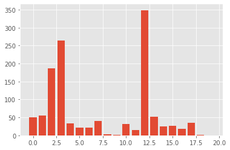

```python
plt.bar(list(range(20)),h1)
```

```python
h2 = np.zeros(len(genres))
for ID in C2:
    l = mov_to_gen[ID]
    for genre in l:
        pos = np.where(genres == genre)
        h2[pos] += 1
```

```
<BarContainer object of 20 artists>
```

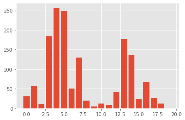

```python
plt.bar(list(range(20)),h2)
```

The most frequent genres for each cluster are:

- **C1**: Drama, Romance, Comedy.
- **C2**: Drama, Action, Thriller, Adventure.

The most common genres of each cluster tend to be together. In this case, Drama, Romance, and Comedy tend to go together in movies. Also, the other characteristic is that they differ from the other clusters genres, which allows to separate the data better: romance and comedy is way different than action and adventure.